# Why Flying During The Thanksgiving Holiday Isn’t All That Bad

## What Airline Is Best For Thanksgiving?

Let’s start by examining the simplest decision an air traveler can make - which airline to fly during the holiday.

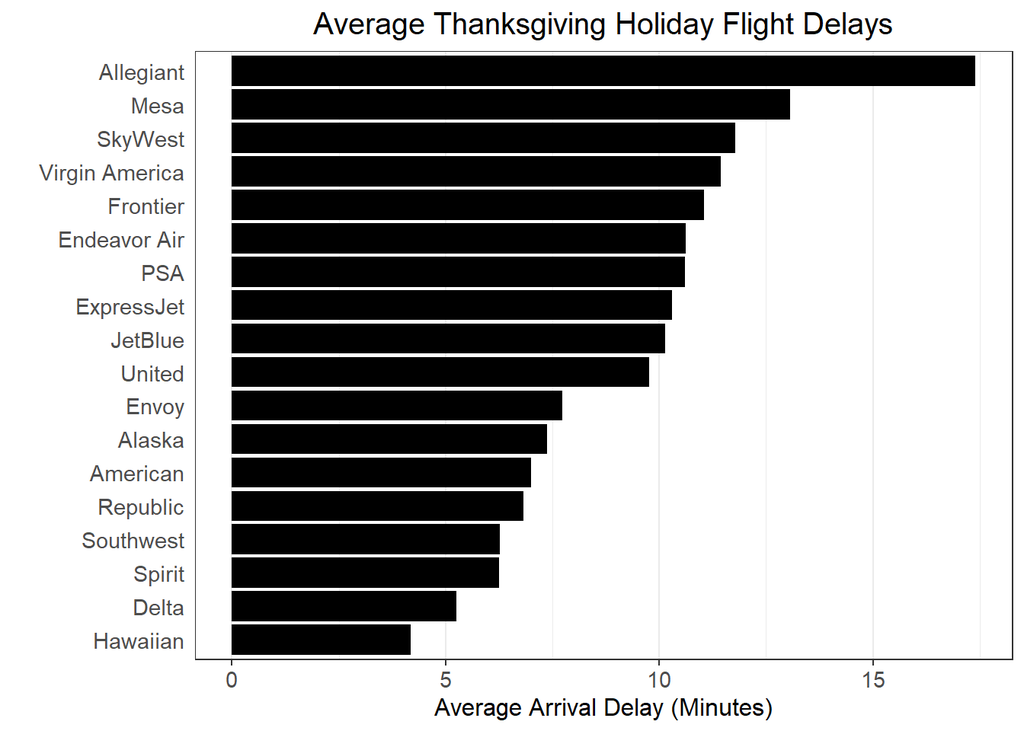

Ultra low-cost carrier Allegiant leads the pack in Thanksgivng delays, which isn’t surprising considering its reputation (but wait, more on this in a second!). Regional airline Mesa Airlines comes next. Hawaiian Airlines has the fewest delays of any airline.

It is clear that focusing on large carriers will make the most sense for our purposes, since consumers are typically unfamiliar with regional airlines that fly under either a single mainline carrier’s brand or multiple brands (when’s the last time you booked a Mesa Airlines flight directly?) and those airlines tend to be available for only a small set of routes (Hawaiian Airlines won’t do you much good unless you’re flying to Hawaii, whereas a larger carrier’s network is likely to cover most major routes).

Among the three major legacy mainline carriers, Delta has the fewest delays, followed by American Airlines, and United performs by far the worst. Southwest performs a little better than American Airlines, and Alaska Airlines (AS) performs a little worse than American Airlines.

Does this change by year, though? How much does our data vary by year?

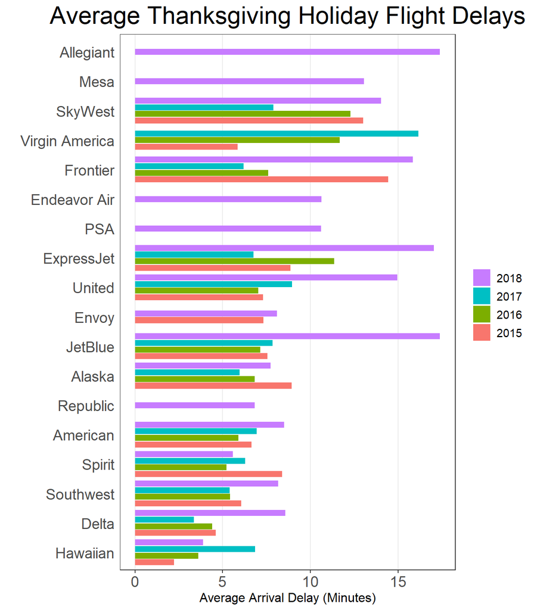

We will examine year-to-year patterns (particularly the horrors of Thanksgiving Sunday 2018) later, but for now, this graph provides a curious revelation: Allegiant did not have any flights during the Thanksgiving holiday before 2018. No wonder its on time performance was so terrible - it only flew on Thanksgiving during the year when delays were by far the worst.

This graph is here to demonstrate that, as we expected, focusing on large, national, major mainline airlines that flew in all four years will make the most sense for our purposes.

We will apply the following criteria for removing airlines:

1. Must have flown flights during Thanksgiving all four years
2. Regional or heavily region-specific airlines (regional airlines would be contracted carriers such as Mesa, heavily region-focused airlines would be like Hawaiian Airlines).
3. Inactive airlines

For this reason, we have decided to remove the following airlines: +Endeavor Air +ExpressJet +Allegiant +Hawaiian Airlines +Envoy Air +PSA Airlines +SkyWest Airlines +Virgin America +Mesa Airlines +Republic Airways

Which leaves us with the following airlines: 1. American Airlines 2. Delta Airlines 3. United Airlines 4. Southwest Airlines 5. Alaska Airlines 6. JetBlue 7. Spirit Airlines 8. Frontier Airlines

These happen to be the eight largest passenger airlines in the United States, so this arrangement makes sense.

We will present these airlines graphically sorted from the largest airline to the smallest (as they are above), and keep this consistent throughout the presentation.

## Regionality of Delays

Let’s now compare flights based on the regions of their departure airports (since most bad airline delays are caused at the origin, as once a flight it in the air it’s hard to delay it much more due to fuel concerns).